# Homework 07

STAT 432

Author

Haoran Sun

Published

October 10, 2026

Use either R or Python.

## Question 1: LDA

Let’s start by estimating the components of LDA. From the lecture notes, for each target point $\mathbf{x}_0$, we find the class label $k$ with the largest score

$$\mathbf{x}_0^{\mathsf T}\boldsymbol{\Sigma}^{-1}\boldsymbol{\mu}_k
-\frac12\boldsymbol{\mu}_k^{\mathsf T}\boldsymbol{\Sigma}^{-1}\boldsymbol{\mu}_k
+\log\pi_k.$$

Thus, we need to estimate:

- the prior probabilities $\pi_k$;
- the mean vector (centroid) $\boldsymbol{\mu}_k$ for each class; and
- the pooled covariance matrix $\boldsymbol{\Sigma}$.

Use saheart.csv, the `SAheart` data from `ElemStatLearn`. The two classes are defined by `chd`, the coronary heart disease indicator. Use all nine other variables as numerical predictors, coding `famhist` as 1 for `Absent` and 2 for `Present`. The following code constructs an $n\times9$ predictor matrix $\mathbf{X}$ and an $n$-entry response vector $\mathbf{y}$, where $n$ is the number of observations.

**R**

```r
heart <- read.csv("data/saheart.csv")
heart$famhist <- factor(heart$famhist, levels = c("Absent", "Present"))
X <- data.matrix(heart[, names(heart) != "chd"])
y <- heart$chd
```

**Python**

```python
import pandas as pd

heart = pd.read_csv("data/saheart.csv")
heart["famhist"] = heart["famhist"].map({"Absent": 1, "Present": 2})
X = heart.drop(columns="chd").to_numpy()
y = heart["chd"].to_numpy()
```

1. Calculate the prior probabilities, class means, and pooled covariance matrix from these data. Use the pooled covariance denominator $n-K$ from the lecture, where $K=2$ is the number of classes.

#### Answer 1(a)

```python
import numpy as np
import pandas as pd

heart = pd.read_csv("data/saheart.csv")
heart["famhist"] = heart["famhist"].map({"Absent": 1, "Present": 2})
predictors = heart.drop(columns="chd").columns
X = heart[predictors].to_numpy(dtype=float)
y = heart["chd"].to_numpy()
n = len(y)
K = 2

# Empirical class priors and class means.
prior_0 = np.mean(y == 0)
prior_1 = np.mean(y == 1)
mean_0 = X[y == 0].mean(axis=0)
mean_1 = X[y == 1].mean(axis=0)

# Center each observation at its own class mean, then pool.
diff_0 = X[y == 0] - mean_0
diff_1 = X[y == 1] - mean_1
cov_matrix = (diff_0.T @ diff_0 + diff_1.T @ diff_1) / (n - K)

print(f"n = {n}; pooled covariance denominator = {n - K}")
```

```
n = 462; pooled covariance denominator = 460
```

```python
print("\nClass counts and prior probabilities:")
```

```
Class counts and prior probabilities:
```

```python
print(pd.DataFrame({
    "Count": [np.sum(y == 0), np.sum(y == 1)],
    "Prior": [prior_0, prior_1]
}, index=pd.Index([0, 1], name="chd")).to_string(float_format="%.4f"))
```

```
     Count  Prior
chd
0      302 0.6537
1      160 0.3463
```

```python
print("\nClass means (rows are predictors):")
```

```
Class means (rows are predictors):
```

```python
print(pd.DataFrame({"Class 0": mean_0, "Class 1": mean_1},
                   index=predictors).to_string(float_format="%.4f"))
```

```
           Class 0  Class 1
sbp       135.4603 143.7375
tobacco     2.6347   5.5249
ldl         4.3442   5.4879
adiposity  23.9691  28.1202
famhist     1.3179   1.6000
typea      52.3675  54.4937
obesity    25.7375  26.6229
alcohol    15.9314  19.1452
age        38.8543  50.2938
```

```python
print("\nPooled within-class covariance matrix:")
```

```
Pooled within-class covariance matrix:
```

```python
print(pd.DataFrame(cov_matrix, index=predictors,
                   columns=predictors).to_string(float_format="%.4f"))
```

```
               sbp  tobacco     ldl  adiposity  famhist    typea  obesity  alcohol      age
sbp       405.4348  14.5852  4.5812    49.1644   0.3370 -15.5877  18.9388  64.4004  95.1339
tobacco    14.5852  19.2426  0.7632     7.5381   0.0158  -2.0573   1.8335  20.5170  22.7654
ldl         4.5812   0.7632  4.0006     6.0327   0.0919   0.3446   2.6601  -2.5329   6.4789
adiposity  49.1644   7.5381  6.0327    56.7529   0.4328  -5.3096  22.7079  16.1190  60.5087
famhist     0.3370   0.0158  0.0919     0.4328   0.2258   0.0811   0.1840   0.7685   0.9974
typea     -15.5877  -2.0573  0.3446    -5.3096   0.0811  95.5656   2.6401   7.9600 -20.2783
obesity    18.9388   1.8335  2.6601    22.7079   0.1840   2.6401  17.6154   4.6894  15.6970
alcohol    64.4004  20.5170 -2.5329    16.1190   0.7685   7.9600   4.6894 598.2766  27.8859
age        95.1339  22.7654  6.4789    60.5087   0.9974 -20.2783  15.6970  27.8859 184.1321
```

2. Use your estimated values to predict the label of each observation in the training data. These are in-sample fitted labels. Provide the confusion matrix, with observed classes in rows and predicted classes in columns. Check that the dimensions of your matrices and vectors match. Calculate the scores yourself for this part.

#### Answer 1(b)

```python
# Solve Sigma @ weights = mean to obtain Sigma^{-1} @ mean.
weights_0 = np.linalg.solve(cov_matrix, mean_0)
weights_1 = np.linalg.solve(cov_matrix, mean_1)

# Calculate one LDA score per observation for each class.
score_0 = X @ weights_0 - 0.5 * (mean_0 @ weights_0) + np.log(prior_0)
score_1 = X @ weights_1 - 0.5 * (mean_1 @ weights_1) + np.log(prior_1)
scores = np.column_stack([score_0, score_1])
predicted = np.argmax(scores, axis=1)

print("X:", X.shape)
```

```
X: (462, 9)
```

```python
print("Class mean vectors:", mean_0.shape, mean_1.shape)
```

```
Class mean vectors: (9,) (9,)
```

```python
print("Pooled covariance:", cov_matrix.shape)
```

```
Pooled covariance: (9, 9)
```

```python
print("Weight vectors:", weights_0.shape, weights_1.shape)
```

```
Weight vectors: (9,) (9,)
```

```python
print("Scores:", scores.shape)
```

```
Scores: (462, 2)
```

```python
print("Observed and predicted labels:", y.shape, predicted.shape)
```

```
Observed and predicted labels: (462,) (462,)
```

```python
confusion = pd.crosstab(
    pd.Series(y, name="Observed"),
    pd.Series(predicted, name="Predicted")
).reindex(index=[0, 1], columns=[0, 1], fill_value=0)
print("\nTraining confusion matrix:")
```

```
Training confusion matrix:
```

```python
print(confusion)
```

```
Predicted    0   1
Observed
0          258  44
1           73  87
```

```python
print(f"\nTraining misclassification rate: {np.mean(predicted != y):.4f}")
```

```
Training misclassification rate: 0.2532
```

3. Perform the same LDA analysis using `MASS::lda` in R or `LinearDiscriminantAnalysis(solver="svd")` in Python, using the same numerical predictors and empirical class priors. Provide the confusion matrix. Do the results match?

#### Answer 1(c)

```python
from sklearn.discriminant_analysis import LinearDiscriminantAnalysis

lda = LinearDiscriminantAnalysis(
    solver="svd", priors=np.array([prior_0, prior_1])
)
lda.fit(X, y)
```

```
LinearDiscriminantAnalysis(priors=array([0.65367965, 0.34632035]))
```

```python
predicted_lda = lda.predict(X)

confusion_lda = pd.crosstab(
    pd.Series(y, name="Observed"),
    pd.Series(predicted_lda, name="Predicted")
).reindex(index=[0, 1], columns=[0, 1], fill_value=0)
print("Scikit-learn LDA training confusion matrix:")
```

```
Scikit-learn LDA training confusion matrix:
```

```python
print(confusion_lda)
```

```
Predicted    0   1
Observed
0          258  44
1           73  87
```

```python
print(f"\nTraining misclassification rate: {np.mean(predicted_lda != y):.4f}")
```

```
Training misclassification rate: 0.2532
```

```python
print("All predictions match part (b):", np.array_equal(predicted_lda, predicted))
```

```
All predictions match part (b): True
```

The predictions and confusion matrix match part (b) exactly. Both methods misclassify 117 of 462 training observations (25.32%).

## Question 2: QDA and marginal screening

In the lecture, ordinary QDA could not be fitted to the handwritten digit sample because its within-class covariance matrices were singular. Let’s consider selecting fewer variables and see whether this helps. For this question, use the full zip-train.csv.gz as the training data and zip-test.csv.gz as the test data, with all ten digit classes. These are the original `zip.train` and `zip.test` data from `ElemStatLearn`. Each file has no header: the first column is the digit label and the remaining 256 columns are pixel values.

Instead of using all 256 predictors, select the 40 with the largest marginal variances in the training data. Here, marginal variance means the variance of one pixel across all training observations. Use the original pixel values without standardizing them, and retain the same selected predictors in the test data.

Use `MASS::qda` in R or `QuadraticDiscriminantAnalysis(tol=1e-8)` in Python.

1. Fit QDA using these 40 predictors and report the test confusion matrix, with observed classes in rows and predicted classes in columns. Also report the test misclassification rate.

#### Answer 2(a)

```python
from sklearn.discriminant_analysis import QuadraticDiscriminantAnalysis
from sklearn.metrics import confusion_matrix

# Use all observations; the first column contains the digit labels.
zip_train = pd.read_csv("data/zip-train.csv.gz", header=None).to_numpy()
zip_test = pd.read_csv("data/zip-test.csv.gz", header=None).to_numpy()
X_train_digits = zip_train[:, 1:]
y_train_digits = zip_train[:, 0].astype(int)
X_test_digits = zip_test[:, 1:]
y_test_digits = zip_test[:, 0].astype(int)

# Rank pixels using only the training data, without standardizing.
pixel_variances = X_train_digits.var(axis=0, ddof=1)
pixel_order = np.argsort(-pixel_variances, kind="stable")
selected_40 = pixel_order[:40]
X_train_40 = X_train_digits[:, selected_40]
X_test_40 = X_test_digits[:, selected_40]

qda_40 = QuadraticDiscriminantAnalysis(tol=1e-8)
qda_40.fit(X_train_40, y_train_digits)
```

```
QuadraticDiscriminantAnalysis(tol=1e-08)
```

```python
predicted_40 = qda_40.predict(X_test_40)

cm_40 = confusion_matrix(y_test_digits, predicted_40, labels=np.arange(10))
error_40 = np.mean(predicted_40 != y_test_digits)
print("Training and test predictor shapes:", X_train_40.shape, X_test_40.shape)
```

```
Training and test predictor shapes: (7291, 40) (2007, 40)
```

```python
print("\nTest confusion matrix:")
```

```
Test confusion matrix:
```

```python
print(pd.DataFrame(
    cm_40,
    index=pd.Index(range(10), name="Observed"),
    columns=pd.Index(range(10), name="Predicted")
))
```

```
Predicted    0    1    2    3    4    5    6    7    8    9
Observed
0          319    0   24    6    2    2    1    0    5    0
1            0  238    5    0   11    0    7    0    3    0
2            8    0  168    8    8    3    0    0    3    0
3            5    0    4  128    0   14    0    0   15    0
4            0    2   13    1  150    1    0    1    7   25
5           12    0    3    5    1  131    0    0    6    2
6            0    0    8    0    1    8  148    0    5    0
7            1    0    6    1    6    0    0  124    2    7
8            1    0   10   12    3    2    0    0  137    1
9            0    0    1    2    7    1    1    4    9  152
```

```python
print(f"\nMisclassified: {np.sum(predicted_40 != y_test_digits)} / {len(y_test_digits)}")
```

```
Misclassified: 312 / 2007
```

```python
print(f"Test misclassification rate: {error_40:.4f} ({error_40:.2%})")
```

```
Test misclassification rate: 0.1555 (15.55%)
```

The test misclassification rate is 0.1555 (15.55%), with 312 of 2,007 test images classified incorrectly.

2. Does the method work? Why do you think it works or does not work?

#### Answer 2(b)

It works pretty well with a misclassification rate below 20%. We are capturing important features of the digits by looking at the 40 pixels with the largest marginal variances.

3. Repeat the analysis using the 10 predictors with the largest marginal variances in the training data. How does the test misclassification rate compare with the 40-predictor version? Why do you think this happens?

#### Answer 2(c)

```python
# Reuse the pixel ranking based only on training-set variances.
selected_10 = pixel_order[:10]
X_train_10 = X_train_digits[:, selected_10]
X_test_10 = X_test_digits[:, selected_10]

qda_10 = QuadraticDiscriminantAnalysis(tol=1e-8)
qda_10.fit(X_train_10, y_train_digits)
```

```
QuadraticDiscriminantAnalysis(tol=1e-08)
```

```python
predicted_10 = qda_10.predict(X_test_10)

cm_10 = confusion_matrix(y_test_digits, predicted_10, labels=np.arange(10))
error_10 = np.mean(predicted_10 != y_test_digits)
print("Test confusion matrix (10 predictors):")
```

```
Test confusion matrix (10 predictors):
```

```python
print(pd.DataFrame(
    cm_10,
    index=pd.Index(range(10), name="Observed"),
    columns=pd.Index(range(10), name="Predicted")
))
```

```
Predicted    0    1   2    3   4   5   6    7   8    9
Observed
0          298    0  11    1   1  16  28    4   0    0
1            0  241  10    0   3   1   1    0   2    6
2           19    2  95   14  14   3  22   21   5    3
3            5    0   6  103   3  42   0    0   7    0
4            1    5  14    0  95   2   4   15  17   47
5           15    0   6   25   4  96   4    2   8    0
6           41    0  15    4   0  18  78    7   5    2
7            4    1   6    0   6   0   1  122   0    7
8            1    2  11   36  12  11   4    1  74   14
9            0    2   9    2  20   0   0   16  10  118
```

```python
print("\nTest error comparison:")
```

```
Test error comparison:
```

```python
print(pd.DataFrame({
    "Predictors": [40, 10],
    "Misclassified": [np.sum(predicted_40 != y_test_digits),
                      np.sum(predicted_10 != y_test_digits)],
    "Test error": [error_40, error_10]
}).to_string(index=False, float_format="%.4f"))
```

```
 Predictors  Misclassified  Test error
         40            312      0.1555
         10            687      0.3423
```

Using 10 predictors increases the test error from 15.55% to 34.23%. Although fewer predictors reduce the number of covariance parameters to estimate, they also discard useful information about digit shapes. Here, the loss of information appears to outweigh the benefit of simpler estimation. Large marginal variance alone does not guarantee that a pixel distinguishes digit classes.

## Question 3: Compare LDA and QDA

In this simulation, we will study how the relative performance of LDA and QDA changes with the true covariance structure. The parameter $\rho$ controls the distribution from which we generate the data; it is not a tuning parameter of LDA or QDA.

Consider a classification problem with two equally likely classes, labeled 1 and 2, and $p=10$ covariates. The first two covariates have the class-conditional distributions

$$\begin{pmatrix}X_1\\X_2\end{pmatrix}\mid Y=1
\sim N_2\left(
\begin{pmatrix}-1\\0\end{pmatrix},
\begin{pmatrix}1&\rho\\\rho&1\end{pmatrix}
\right),$$

$$\begin{pmatrix}X_1\\X_2\end{pmatrix}\mid Y=2
\sim N_2\left(
\begin{pmatrix}1\\0\end{pmatrix},
\begin{pmatrix}1&-\rho\\-\rho&1\end{pmatrix}
\right).$$

In both classes, the remaining eight covariates are independent standard normal variables, independent of the first two. Consider

$$\rho\in\{0,0.2,0.4,0.6,0.8,0.9\}.$$

For each value of $\rho$, generate 100 training observations and 1,000 independent test observations from each class. Fit ordinary LDA and QDA using all 10 covariates and equal class priors. Estimate the class means from the training data, with one pooled covariance matrix for LDA and one full covariance matrix per class for QDA. Set a random seed and report it.

1. Generate one dataset for each value of $\rho$. Fit both methods and calculate their test misclassification rates. Within each setting, use the same training and test observations for the two methods.

#### Answer 3(a)

```python
seed_3a = 43273
rng_3a = np.random.default_rng(seed_3a)
rhos = [0, 0.2, 0.4, 0.6, 0.8, 0.9]

def generate_q3_data(rho, n_per_class, rng):
    predictors_by_class = []
    labels_by_class = []
    for label, mean_x1, correlation in [(1, -1, rho), (2, 1, -rho)]:
        first_two = rng.multivariate_normal(
            mean=[mean_x1, 0],
            cov=[[1, correlation], [correlation, 1]],
            size=n_per_class
        )
        noise = rng.standard_normal((n_per_class, 8))
        predictors_by_class.append(np.column_stack([first_two, noise]))
        labels_by_class.append(np.full(n_per_class, label))
    return np.vstack(predictors_by_class), np.concatenate(labels_by_class)

def run_q3_experiment(rho, rng):
    X_train_sim, y_train_sim = generate_q3_data(rho, 100, rng)
    X_test_sim, y_test_sim = generate_q3_data(rho, 1000, rng)
    lda_sim = LinearDiscriminantAnalysis(solver="svd", priors=[0.5, 0.5])
    qda_sim = QuadraticDiscriminantAnalysis(priors=[0.5, 0.5], tol=1e-8)
    lda_sim.fit(X_train_sim, y_train_sim)
    qda_sim.fit(X_train_sim, y_train_sim)
    lda_error = np.mean(lda_sim.predict(X_test_sim) != y_test_sim)
    qda_error = np.mean(qda_sim.predict(X_test_sim) != y_test_sim)
    return lda_error, qda_error

results_3a = []
for rho in rhos:
    lda_error, qda_error = run_q3_experiment(rho, rng_3a)
    results_3a.append({"rho": rho, "LDA test error": lda_error,
                       "QDA test error": qda_error})

results_3a = pd.DataFrame(results_3a)
print(f"Random seed: {seed_3a}")
```

```
Random seed: 43273
```

```python
print("Each setting: 200 training observations and 2,000 test observations.")
```

```
Each setting: 200 training observations and 2,000 test observations.
```

```python
print(results_3a.to_string(index=False, float_format="%.4f"))
```

```
   rho  LDA test error  QDA test error
0.0000          0.1845          0.2155
0.2000          0.1760          0.1955
0.4000          0.1685          0.1765
0.6000          0.1855          0.1900
0.8000          0.1510          0.1265
0.9000          0.1650          0.0870
```

2. At each fixed value of $\rho$, repeat the experiment 50 times, generating new training and test observations in each repetition. Plot average test error against $\rho$ in one figure, with one curve for LDA and one for QDA. These curves compare performance across different data-generating distributions.

#### Answer 3(b)

```python
import matplotlib.pyplot as plt

seed_3b = 43274
rng_3b = np.random.default_rng(seed_3b)
repetitions = 50
# Dimensions: rho settings, repetitions, methods (LDA then QDA).
errors_3b = np.empty((len(rhos), repetitions, 2))
for i, rho in enumerate(rhos):
    for repetition in range(repetitions):
        # Each call generates new training and test data for both methods.
        errors_3b[i, repetition] = run_q3_experiment(rho, rng_3b)

average_errors = errors_3b.mean(axis=1)
results_3b = pd.DataFrame({
    "rho": rhos,
    "Mean LDA test error": average_errors[:, 0],
    "Mean QDA test error": average_errors[:, 1]
})
print(f"Random seed: {seed_3b}; repetitions per rho: {repetitions}")
```

```
Random seed: 43274; repetitions per rho: 50
```

```python
print(results_3b.to_string(index=False, float_format="%.4f"))
```

```
   rho  Mean LDA test error  Mean QDA test error
0.0000               0.1676               0.1948
0.2000               0.1708               0.1981
0.4000               0.1670               0.1896
0.6000               0.1703               0.1760
0.8000               0.1705               0.1374
0.9000               0.1658               0.0974
```

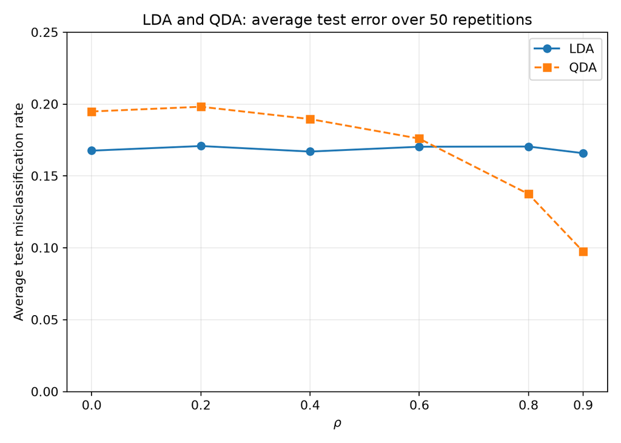

```python
fig, ax = plt.subplots(figsize=(7, 5))
ax.plot(rhos, average_errors[:, 0], "o-", label="LDA")
ax.plot(rhos, average_errors[:, 1], "s--", label="QDA")
ax.set(xlabel=r"$\rho$", ylabel="Average test misclassification rate",
       title="LDA and QDA: average test error over 50 repetitions",
       xticks=rhos, ylim=(0, 0.25))
ax.legend()
ax.grid(alpha=0.25)
fig.tight_layout()
plt.show()
```

3. Compare the two methods at small and large values of $\rho$. How does changing the true covariance structure affect their relative performance? Explain the pattern using their covariance assumptions and the bias-variance trade-off. How can the eight noise covariates affect performance even though they contain no information about the class label?

#### Answer 3(c)

At small $\rho$, LDA has lower average test error. The class covariance matrices are identical at $\rho=0$ and similar for small $\rho$, so LDA’s shared-covariance assumption introduces little bias while requiring fewer parameters than QDA. QDA estimates separate covariance matrices, increasing estimation variance without much benefit here.

At large $\rho$, the classes have strong correlations with opposite signs. QDA captures these different covariance structures and the resulting curved decision boundary, reducing bias enough to outweigh its higher variance. In our simulation, QDA outperforms LDA at $\rho=0.8$ and $0.9$, while LDA’s error stays near 17%.

The eight noise predictors add no class information but require estimating extra means, variances, and covariances. Random sample differences can therefore affect predictions and increase estimation variance, especially for QDA, which estimates a full covariance matrix separately for each class.

## Question 4: Create and use an LDA/QDA analysis skill

In Homework 5, you created a skill for formatting plots. Now create a reusable skill that guides an AI agent through an LDA/QDA analysis and produces a concise statistical report. You may work with AI to design and write the skill; you do not need to write every line yourself.

1. **Define the skill.** Write a single `SKILL.md` file no larger than **5 KB (5,000 bytes)**. Define the agent’s behavior, analysis guidelines, and expected report structure. Keep the skill independent of this question: provide the dataset, response, and predictors separately when invoking it. The skill may guide the agent to explore lower-dimensional representations, such as principal component analysis (PCA), or to blend the class probabilities predicted by LDA and QDA. Keep all classifiers based on LDA, QDA, or their combination. Configure the skill to load **only when you explicitly invoke it**. Use your AI tool’s invocation settings, or keep the file outside automatically loaded skill folders and supply it only in an explicit request.

Your skill must require a clearly readable analysis report of **at most one printed page**, containing a figure, a table, and numerical model-fitting results. You may specify the type and style of figures and tables you want the AI to produce. All instructions in the skill must be independent of the actual dataset, its variable names, and its observed results. The report should briefly describe the candidate models, the cross-validation procedure and results, the selected model, and its estimated prediction error. It should explain the main findings and any limitations.

#### Answer 4(a)

```markdown
---
name: lda-qda-report
description: Compare ordinary LDA and QDA and produce a one-page statistical report only when explicitly invoked with a dataset, response, and predictors.
---

# LDA/QDA report

Keep this file outside automatically loaded skill folders. Apply it only when the user explicitly supplies this file and requests its use.

Use the dataset, response, predictors, and categorical coding supplied in the invocation. Compare only ordinary LDA and QDA, with empirical class priors and no regularization, feature selection, PCA, or model combinations.

1. Report a random seed. Reserve a stratified 30% test set before comparing models. Use the remaining 70% for model selection.
2. Compare LDA and QDA using the same shuffled, stratified five-fold cross-validation splits within the training data. Use misclassification rate. Estimate means and covariances within each fold; fit any necessary preprocessing only on that fold's training portion. Report fitting failures rather than silently changing the models.
3. Review the analysis using training and cross-validation results only. Select the model with the smaller mean cross-validation error; break an exact tie in favor of LDA. Refit it on all training observations and evaluate it once on the reserved test set. Do not revise the skill or model choice based on test results.
4. Produce a readable report of at most one printed page. Include a short methods paragraph, a table of both models' cross-validation errors, a labeled figure comparing those errors, the selected model, and its test misclassification count and rate. State training/test sizes, seed, fitted class counts or priors, and the covariance assumptions. Briefly explain the findings and limitations, including uncertainty from one split. Verify that the report fits one page.
```

2. **Apply the skill.** Explicitly invoke your skill to analyze the `SAheart` data from Question 1, using the same response and predictor coding. Ask the agent to seek the best predictive performance within the LDA/QDA methods allowed by your skill. Include ordinary LDA and QDA as comparisons; the extensions above are optional. Reserve a test set before choosing models. Use the same cross-validation folds within the training data to compare candidates and select any settings. Estimate any preprocessing, including an embedding, using only the training observations in each fold. Refit the selected model and preprocessing on all training observations, then evaluate the fitted classifier once on the reserved test set. Use misclassification rate to compare performance, and report your random seed.

#### Answer 4(b)

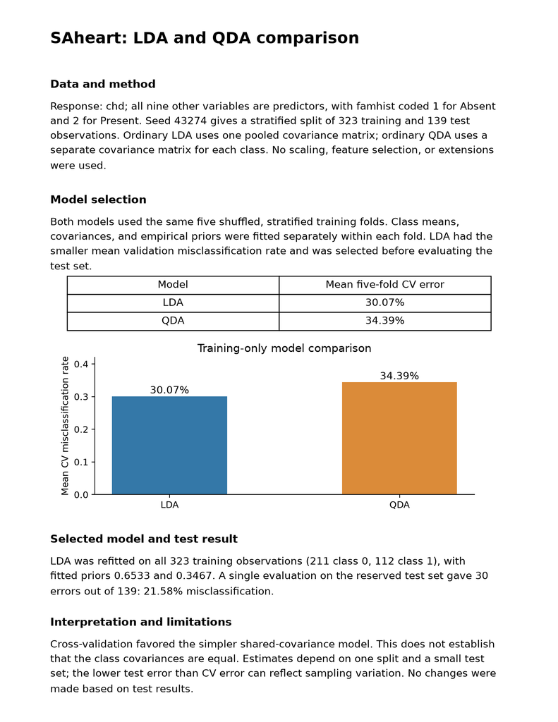

3. **Review and submit.** Check the agent’s analysis and make any skill revisions using only training and cross-validation results. Append the final one-page analysis report and the complete contents of your `SKILL.md` to your homework report. State the file size and briefly explain how you enabled explicit invocation, including the prompt used to apply the skill. The one-page limit applies to the analysis report; the appended skill and this explanation are outside that limit.

Your skill and analysis report will be reviewed and graded by other students through peer evaluation.

#### Answer 4(c)

The final `lda-qda-report/SKILL.md` is **1814 bytes**. It is kept in the homework directory, outside automatically loaded skill folders, and is supplied only for an explicit request. The invocation for this analysis was:

> Apply `lda-qda-report/SKILL.md` to `data/saheart.csv`. Use `chd` as the response and all nine other variables as predictors, coding `famhist` as 1 for Absent and 2 for Present. Compare only ordinary LDA and QDA to seek the lower prediction error. Use seed 43274, a stratified 70/30 training/test split, and the same five stratified cross-validation folds for both models. Select using training cross-validation, then refit and evaluate the selected model once on the reserved test set. Produce the required one-page report.

Before test evaluation, the split and fold checks were reviewed and LDA was selected using cross-validation. No skill revisions were needed, and no changes were made based on the test results. The report is also saved as the one-page `q4-report.pdf`.